# Final Project Appendix

utsab

November 12, 2017

```r
library(knitr)
setwd("~/class/cs495/project")
read_chunk("proj_data.R")
knitr::opts_chunk$set(echo = TRUE)
```

## Steps to setup data

### Step 1: Load the data in gephi

The files were in GEXF format. I loaded the files in gephi and explored different layouts to visualize the network data.

```r
# Load Libraries
library(ggplot2)
library(GGally)
library(igraph)
library(ergm)
library(scales)
library(dplyr)
library(network)
library(latticeExtra)
library(intergraph)
library(sand)
source('lab2-utils.R')
source('invlogit.R')
source('mycugtest.R')
source('myqaptest.R')
path <- "~/class/cs495/project"
setwd(path)
```

### Step 3: Export the node and edge csv file from Gephi

Since I could not load the GEXF file in R, I had to export the edge and node files as CSV file from gephi and read the table in R and write as a graph file.

```r
#import nodes and edges for day 1 and day 2
links_day1 <- read.csv("edgelist.csv", stringsAsFactors=F)
nodes_day1 <- read.csv("nodelist.csv", stringsAsFactors=F)
links_day2 <- read.csv("edgelist-1.csv", stringsAsFactors=F)
nodes_day2 <- read.csv("nodelist-1.csv", stringsAsFactors=F)
```

### Step 3: Convert edge and node data into igraph

```r
# create graph file
day1 <- graph.data.frame(links_day1, vertices=nodes_day1, directed=F)
day2 <- graph.data.frame(links_day2, vertices=nodes_day2, directed=F)
```

### Step 4: Summary

```r
summary(day1)
```

```
## IGRAPH UN-- 236 5899 --
## + attr: name (v/c), Label (v/n), timeset (v/l), X0 (v/c), X1
## | (v/c), Type (e/c), Id (e/n), Label (e/l), timeset (e/l), Weight
## | (e/n), X2 (e/n), X3 (e/n), Calc.Weight (e/n)
```

```r
summary(day2)
```

```
## IGRAPH UN-- 238 5539 --
## + attr: name (v/c), Label (v/n), timeset (v/l), X0 (v/c), X1
## | (v/c), Type (e/c), Id (e/n), Label (e/l), timeset (e/l), Weight
## | (e/n), X2 (e/n), X3 (e/n), Calc.Weight (e/n)
```

```r
summary(E(day1)$Weight)
```

```
##     Min.  1st Qu.   Median     Mean  3rd Qu.     Max.
## -1.00000 -1.00000 -0.39790  0.01258  0.73240  3.84100
```

```r
summary(E(day2)$Weight)
```

```
##     Min.  1st Qu.   Median     Mean  3rd Qu.     Max.
## -1.00000 -1.00000 -0.04576  0.14890  0.95420  3.74300
```

```r
degr <- read.csv("grddeg.csv") #degree by grade table
degr$Day <- as.factor(degr$Day)
degr$Gender <- as.factor(degr$Gender)
```

### Degree Distribution by Grade and Gender

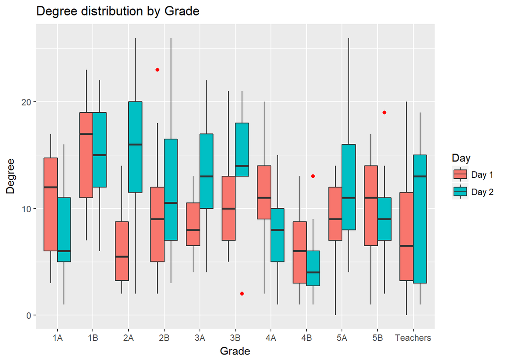

```r
g <- ggplot(degr, aes(x=Label, y=Degree,fill=Day ))
g <- g + geom_boxplot(outlier.color = 'red')
g <- g + xlab("Grade")+ylab("Degree") +ggtitle("Degree distribution by Grade")
print(g)
```

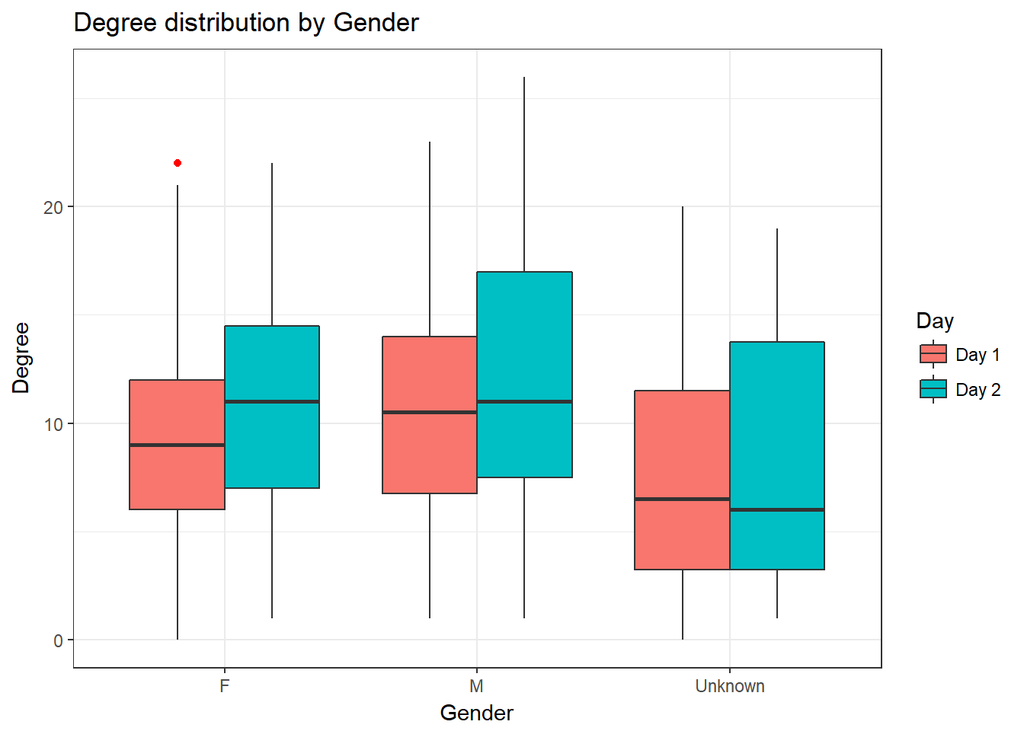

```r
g <- ggplot(degr, aes(x=Gender, y=Degree,fill=Day ))
g <- g + geom_boxplot(outlier.color = 'red')
g <- g + xlab("Gender")+ylab("Degree") +
  ggtitle("Degree distribution by Gender")+ theme_bw()
print(g)
```

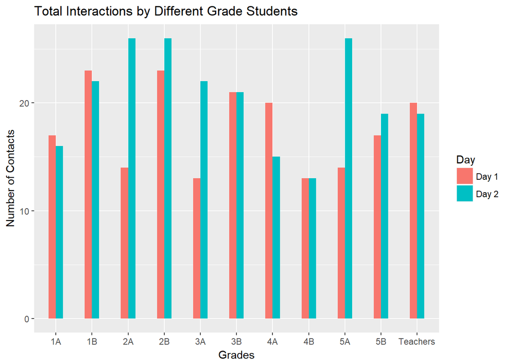

```r
ggplot(degr, aes(y=Degree, x=Label)) +
  geom_col(aes(fill = Day), width =0.4,position = "dodge") +
  xlab("Grades")+ylab("Number of Contacts") +ggtitle("Total Interactions by Different Grade Students")
```

### Heatmap of interactions by Grade

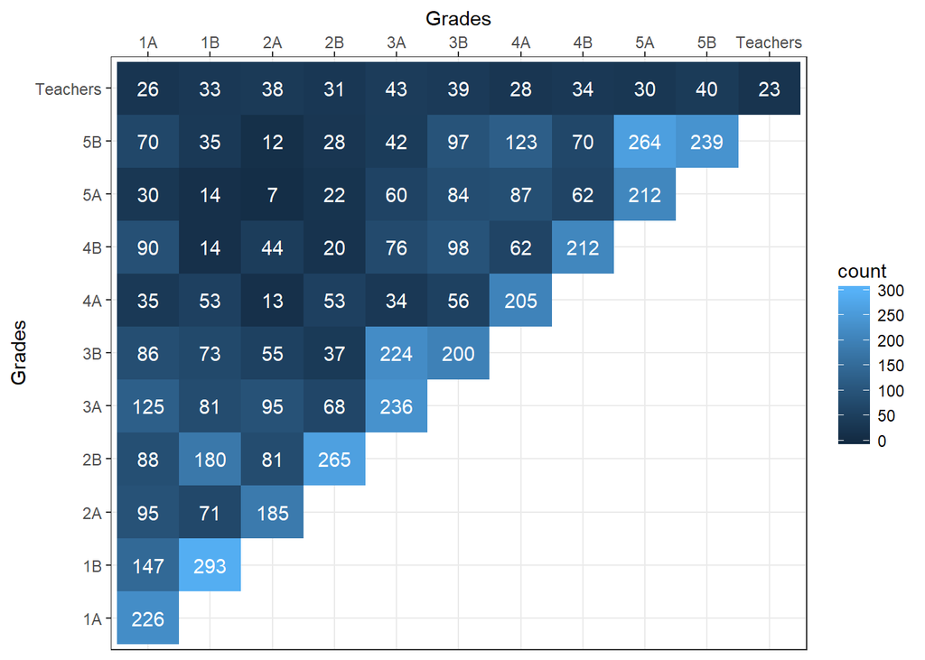

```r
# distribution of number of contacts by grades heatmap
dat <- read.csv("dat.csv", header=TRUE,sep=",",stringsAsFactors=F)
# plot
p <- ggplot(dat, aes(x = x, y = y)) + geom_bin2d(bins = 10)
# Get data - this includes counts and x,y coordinates
newdat <- ggplot_build(p)$data[[1]]
# add in text labels
p + geom_text(data=newdat, aes((xmin + xmax)/2, (ymin + ymax)/2,
                               label=count), col="white")+
  scale_fill_gradientn(limits=c(0,300), breaks=seq(0, 300, by=50),colors=c(high = "#132B43", low = "#56B1F7"))+
  scale_x_discrete(position = "top") +xlab("Grades")+ylab("Grades")+
  theme_bw()
```

### Data pre-processing

```r
# Delete edges with weight less than 1
edges_d1 <- E(day1)[E(day1)$Weight < 1]
edges_d2 <- E(day2)[E(day2)$Weight < 1]
day1 <- delete_edges(day1, edges_d1)
day2 <- delete_edges(day2, edges_d2)
# Delete isolate degree
day1 <- delete_vertices(day1,V(day1)[degree(day1)==0])
day2 <- delete_vertices(day2,V(day2)[degree(day2)==0])


## add grade and age attribute
ageTable <- data.frame(Grade=c("1A", "1B", "2A", "2B", "3A", "3B", "4A", "4B", "5A","5B","Teachers"),
                       Age=c(1,1,2,2,3,3,4,4,5,5,20))
grade_1 <- data.frame(Grade=as.factor(V(day1)$X0))
grade_2 <- data.frame(Grade=as.factor(V(day2)$X0))

grade_1 <- grade_1 %>%
  inner_join(ageTable, by ="Grade")

grade_2 <- grade_2 %>%
  inner_join(ageTable, by ="Grade")


day_1<-set_vertex_attr(day1, "Age", index = V(day1),value=as.numeric(grade_1$Age))
V(day1)$Age <- as.numeric(grade_1$Age)

day_1<-set_vertex_attr(day1, "Grade", index = V(day1),value=as.character(grade_1$Age))
V(day1)$Grade <- as.character(grade_1$Age)
V(day1)$Grade[V(day1)$Grade=="10"]="Teacher"

day_2<-set_vertex_attr(day2, "Age", index = V(day2),value=as.numeric(grade_2$Age))
V(day2)$Age <- as.numeric(grade_2$Age)

day2<-set_vertex_attr(day2, "Grade", index = V(day2),value=as.character(grade_2$Age))
V(day2)$Grade <- as.character(grade_2$Age)
V(day2)$Grade[V(day2)$Grade=="10"]="Teacher"



day1.deg <- data.frame(Degree=graph.strength(day1), Grade=V(day1)$Grade)
day1.deg <- day1.deg[day1.deg$Grade != 20,]
day1.deg$Grade <- as.factor(day1.deg$Grade)

day2.deg <- data.frame(Degree=graph.strength(day2), Grade=V(day2)$Grade)
day2.deg <- day2.deg[day2.deg$Grade != 20,]
day2.deg$Grade <- as.factor(day2.deg$Grade)
```

### Degree Distribution Histogram

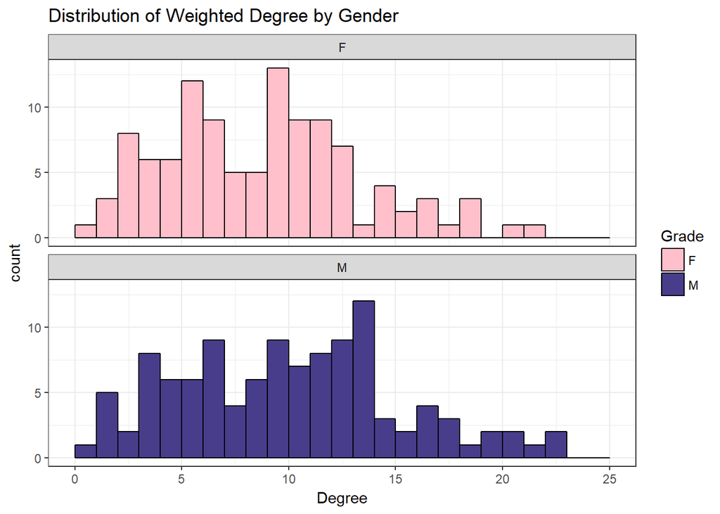

```r
# Degree distribution histogram
day1.deg <- data.frame(Degree=graph.strength(day1), Sex=V(day1)$X1)
day1.deg <- day1.deg[day1.deg$Sex != "Unknown",]
day1.deg$Sex <- as.factor(day1.deg$Sex)


g <- ggplot(data=day1.deg, aes(x=Degree))
g <- g + geom_histogram(breaks=seq(0,25, by=1), col="black",aes(fill=Sex))
g <- g + scale_fill_manual("Grade", values = c("pink","darkslateblue")) + facet_wrap(~Sex,ncol = 1)
g <- g + ggtitle ("Distribution of Weighted Degree by Gender") + theme_bw()
print(g)
```

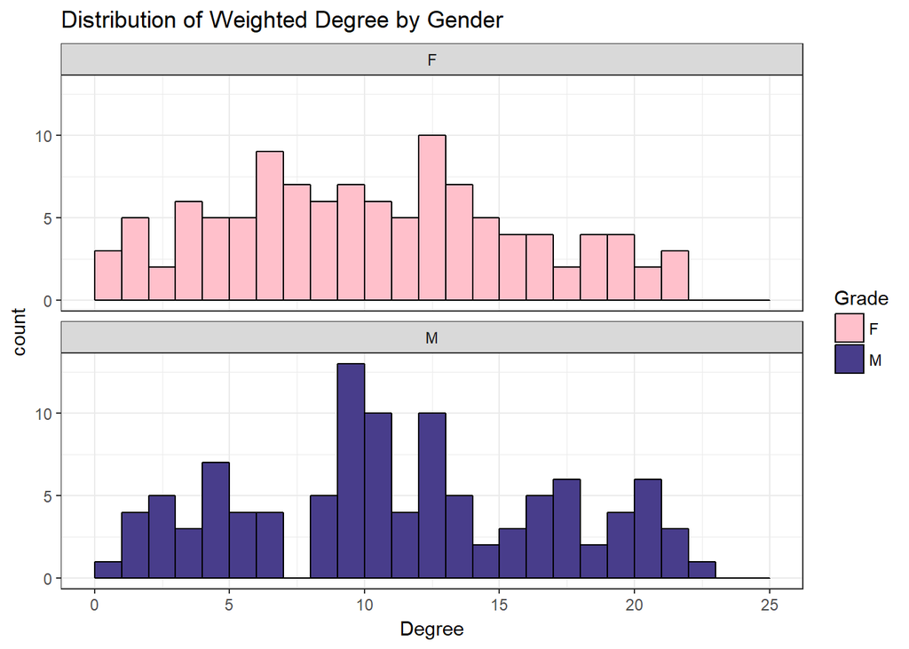

```r
day2.deg <- data.frame(Degree=graph.strength(day2), Sex=V(day2)$X1)
day2.deg <- day2.deg[day2.deg$Sex != "Unknown",]
day2.deg$Sex <- as.factor(day2.deg$Sex)


g <- ggplot(data=day2.deg, aes(x=Degree))
g <- g + geom_histogram(breaks=seq(0,25, by=1), col="black",aes(fill=Sex))
g <- g + scale_fill_manual("Grade", values = c("pink","darkslateblue")) + facet_wrap(~Sex,ncol = 1)
g <- g + ggtitle ("Distribution of Weighted Degree by Gender") + theme_bw()
print(g)
```

### Network properties

```r
## connected

is.connected(day1)
```

```
## [1] TRUE
```

```r
is.connected(day2)
```

```
## [1] TRUE
```

```r
is.simple(day1)
```

```
## [1] TRUE
```

```r
is.simple(day2)
```

```
## [1] TRUE
```

```r
diameter(day1)
```

```
## [1] 10
```

```r
diameter(day2)
```

```
## [1] 9
```

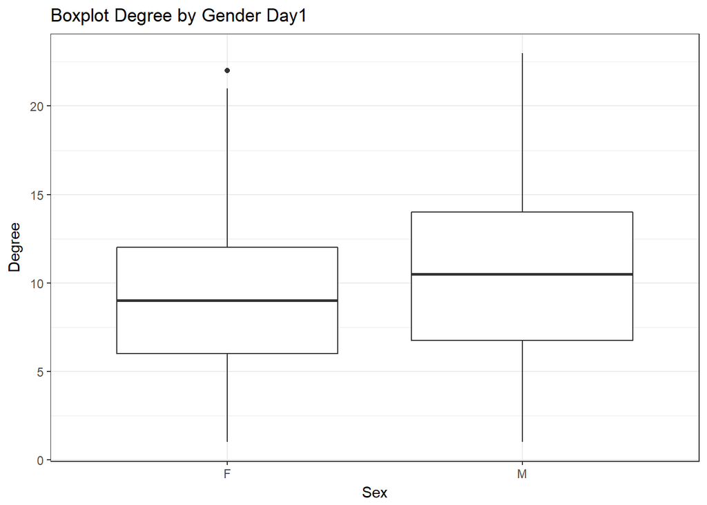

```r
# ggplot boxplot
g <- ggplot(day1.deg, aes(x=Sex, y=Degree ))
g <- g + geom_boxplot()+ggtitle("Boxplot Degree by Gender Day1")+theme_bw()
print(g)
```

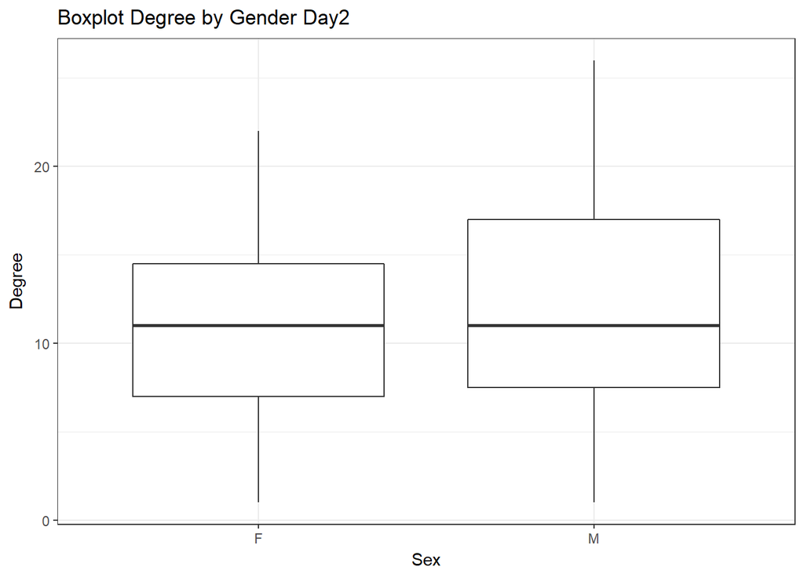

```r
g <- ggplot(day2.deg, aes(x=Sex, y=Degree ))
g <- g + geom_boxplot()+ggtitle("Boxplot Degree by Gender Day2")+theme_bw()
print(g)
```

### Giant Components

```r
# decompose into smaller communities
components <- decompose(day1, min.vertices = 2)
sapply(components,vcount)
```

```
## [1] 234
```

```r
giant_1 <- components[[1]]
summary(giant_1)
```

```
## IGRAPH UN-- 234 1148 --
## + attr: name (v/c), Label (v/n), timeset (v/l), X0 (v/c), X1
## | (v/c), Age (v/n), Grade (v/c), Type (e/c), Id (e/n), Label
## | (e/l), timeset (e/l), Weight (e/n), X2 (e/n), X3 (e/n),
## | Calc.Weight (e/n)
```

```r
components <- decompose(day2, min.vertices = 2)
sapply(components,vcount)
```

```
## [1] 235
```

```r
giant_2 <- components[[1]]
summary(giant_2)
```

```
## IGRAPH UN-- 235 1328 --
## + attr: name (v/c), Label (v/n), timeset (v/l), X0 (v/c), X1
## | (v/c), Age (v/n), Grade (v/c), Type (e/c), Id (e/n), Label
## | (e/l), timeset (e/l), Weight (e/n), X2 (e/n), X3 (e/n),
## | Calc.Weight (e/n)
```

### Centrality Measures Corr Plot

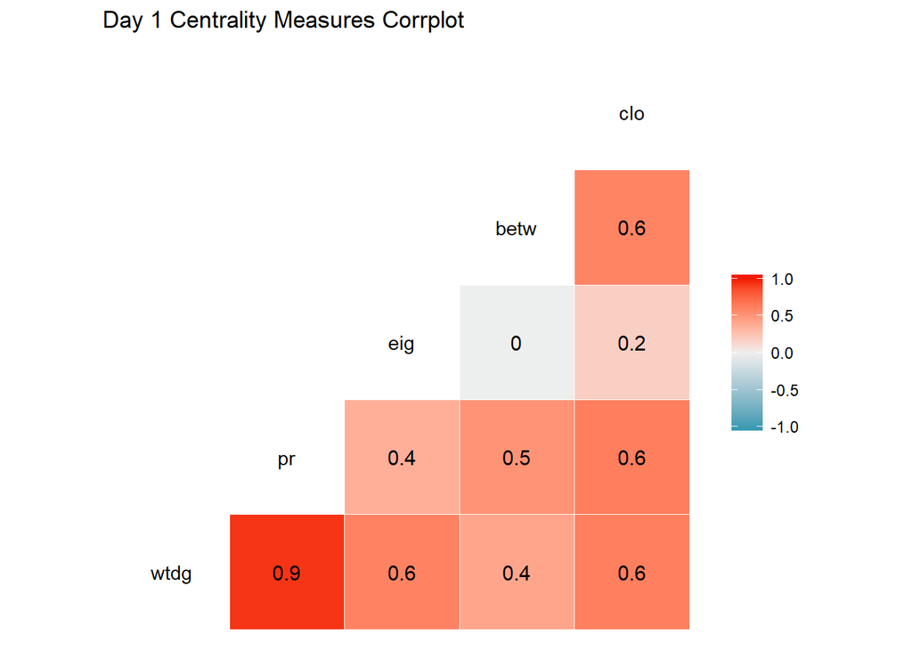

```r
# Centrality measures
giant_1.dg <- degree(giant_1, normalized = TRUE)
giant_1.indg <-degree(giant_1, mode=c("in"),normalized = TRUE)
giant_1.outdg <-degree(giant_1, mode=c("out"),normalized = TRUE)
giant_1.wtdg <-graph.strength(giant_1)
giant_1.bet <- betweenness(giant_1, normalized =TRUE, weights = NULL)
giant_1.clo <- closeness(giant_1, normalized = TRUE,weights = NULL)
giant_1.pr <- page_rank(giant_1)
giant_1.eig <- eigen_centrality(giant_1, directed = FALSE)

giant_1.cent <- data.frame(
                         wtdg=giant_1.wtdg,
                         pr=giant_1.pr$vector,
                         eig=giant_1.eig$vector,
                         betw=giant_1.bet,
                         clo=giant_1.clo)


# ggcorr
ggcorr(giant_1.cent, label = TRUE)+ggtitle("Day 1 Centrality Measures Corrplot")
```

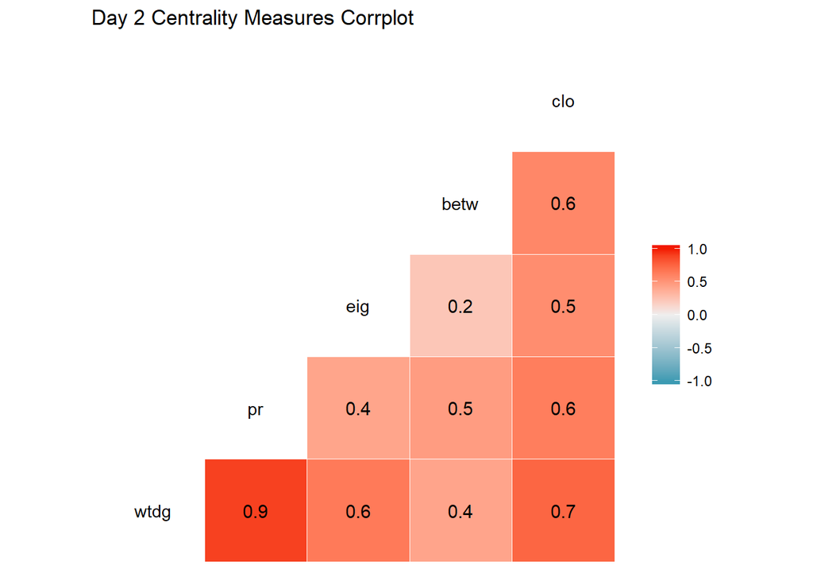

```r
giant_2.dg <- degree(giant_2, normalized = TRUE)
giant_2.wtdg <-graph.strength(giant_2)
giant_2.bet <- betweenness(giant_2, normalized =TRUE,weights = NULL)
giant_2.clo <- closeness(giant_2, normalized = TRUE, weights = NULL)
giant_2.pr <- page_rank(giant_2)
giant_2.eig <- eigen_centrality(giant_2, directed = FALSE)

giant_2.cent <- data.frame(
                           wtdg=giant_2.wtdg,
                           pr=giant_2.pr$vector,
                           eig=giant_2.eig$vector,
                           betw=giant_2.bet,
                           clo=giant_2.clo)

# ggcorr
ggcorr(giant_2.cent, label = TRUE)+ggtitle("Day 2 Centrality Measures Corrplot")
```

### Betweeness and Closeness Distributon

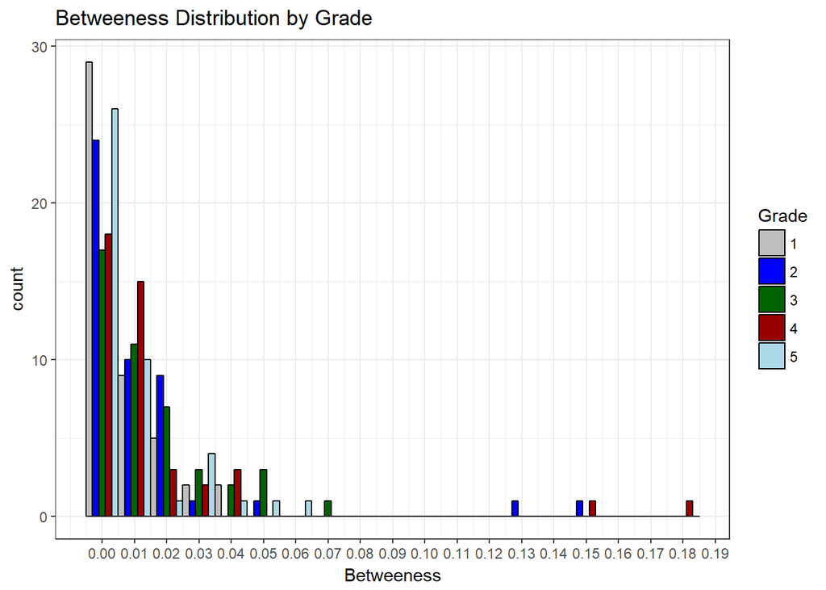

```r
# Betweeness/Closeness distribution
Grade <- factor(V(giant_1)$Grade)
giant_1.df <-data.frame(Betweeness=giant_1.bet,Closeness=giant_1.clo, Grade=Grade)
giant_1.df<-giant_1.df[giant_1.df$Grade!=20,]
g <- ggplot(data=giant_1.df,aes(x=Betweeness, fill=Grade))
g <- g + geom_histogram(position= "dodge", binwidth = .01, aes(y=..count..),color="black")
g <- g + scale_x_continuous(breaks = seq(0,0.5,by=0.01))
g <- g + scale_fill_manual("Grade", values = c("gray", "blue", "dark green","#990000", "light blue", "light green"))
g <- g + ggtitle ("Betweeness Distribution by Grade") + theme_bw()
print(g)
```

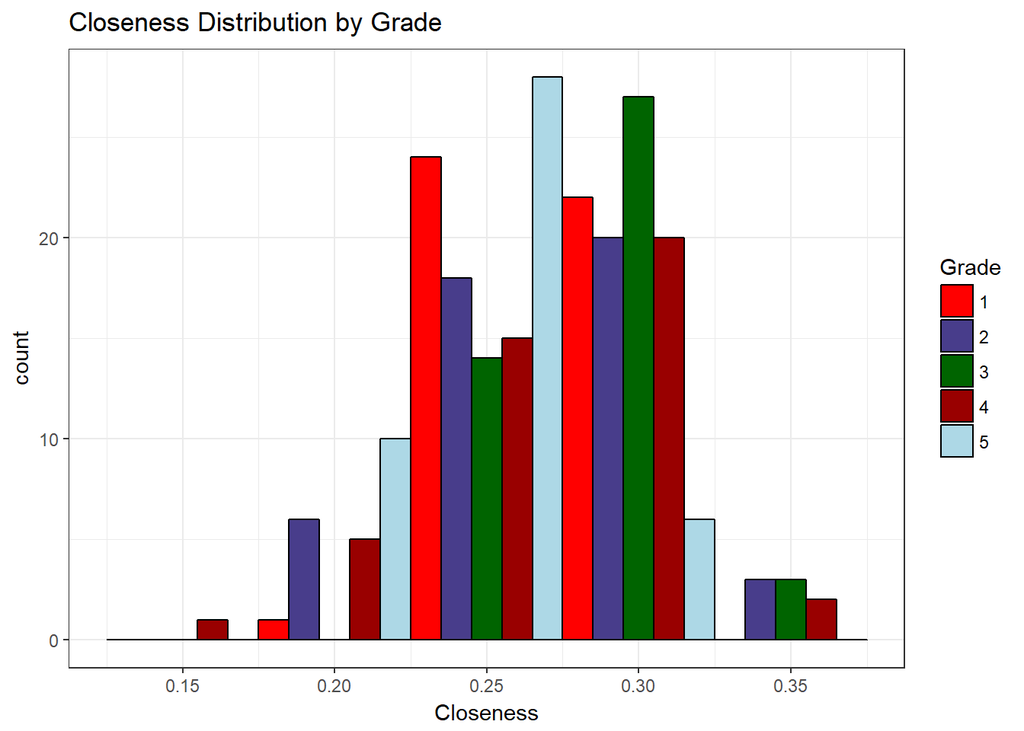

```r
g <- ggplot(data=giant_1.df,aes(x=Closeness, fill=Grade))
g <- g + geom_histogram(position= "dodge", binwidth = .05, aes(y=..count..),color="black")
g <- g + scale_x_continuous(breaks = seq(0,0.5,by=0.05))
g <- g + scale_fill_manual("Grade", values = c("red", "darkslateblue", "dark green","#990000", "light blue", "light green", "orange", "yellow","purple","gray","plum"))
g <- g + ggtitle ("Closeness Distribution by Grade") + theme_bw()
print(g)
```

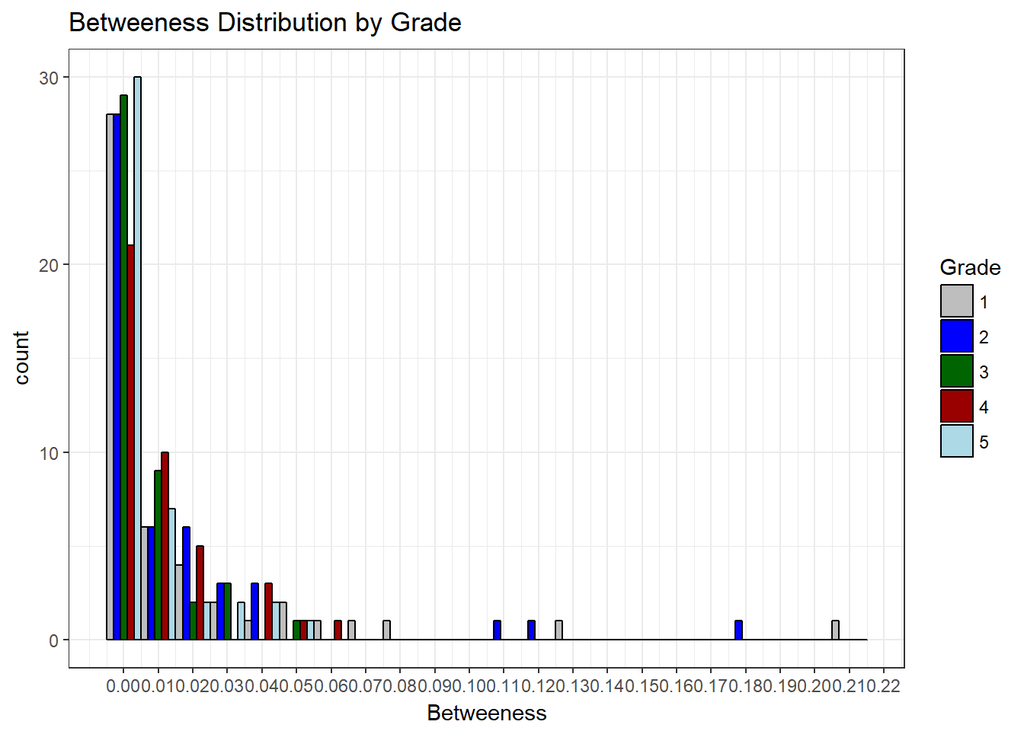

```r
Grade <- factor(V(giant_2)$Grade)
giant_2.df <-data.frame(Betweeness=giant_2.bet,Closeness=giant_2.clo, Grade=Grade)
giant_2.df<-giant_2.df[giant_2.df$Grade!=20,]

g <- ggplot(data=giant_2.df,aes(x=Betweeness, fill=Grade))
g <- g + geom_histogram(position= "dodge", binwidth = .01, aes(y=..count..),color="black")
g <- g + scale_x_continuous(breaks = seq(0,0.5,by=0.01))
g <- g + scale_fill_manual("Grade", values = c("gray", "blue", "dark green","#990000", "light blue", "light green"))
g <- g + ggtitle ("Betweeness Distribution by Grade") + theme_bw()
print(g)
```

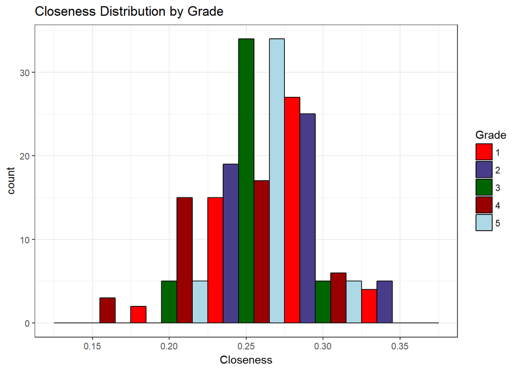

```r
g <- ggplot(data=giant_2.df,aes(x=Closeness, fill=Grade))
g <- g + geom_histogram(position= "dodge", binwidth = .05, aes(y=..count..),color="black")
g <- g + scale_x_continuous(breaks = seq(0,0.5,by=0.05))
g <- g + scale_fill_manual("Grade", values = c("red", "darkslateblue", "dark green","#990000", "light blue", "light green", "orange", "yellow","purple","gray","plum"))
g <- g + ggtitle ("Closeness Distribution by Grade") + theme_bw()
print(g)
```

### ERGM Models

```r
# ERGM Modelling
# Load saved Model files
par(mfcol=c(1,1))
## save(ga_1.net,ga_2.net,file="network-ga.Rdata")
## ga_1.net <- asNetwork(giant_1)
## ga_2.net <- asNetwork(giant_2)

load("network-ga.Rdata")
load("day1-model-ii.Rdata")
```

### Model 1 for Day 1

simple model no mcmc stored

```r
## ga_1.m1 <- ergm(ga_1.net ~ edges + nodemix("X1", base=c(-1,-2,-3)))
## ga_1.m1.gof <- gof(ga_1.m1)
summary(ga_1.m1)
```

```
##
## ==========================
## Summary of model fit
## ==========================
##
## Formula:   ga_1.net ~ edges + nodemix("X1", base = c(-1, -2, -3))
##
## Iterations:  6 out of 20
##
## Monte Carlo MLE Results:
##            Estimate Std. Error MCMC % p-value
## edges      -3.29971    0.09937      0 < 1e-04 ***
## mix.X1.F.F  0.30291    0.11672      0 0.00946 **
## mix.X1.F.M -0.08278    0.11159      0 0.45822
## mix.X1.M.M  0.51647    0.11317      0 < 1e-04 ***
## ---
## Signif. codes:  0 '***' 0.001 '**' 0.01 '*' 0.05 '.' 0.1 ' ' 1
##
##      Null Deviance: 37792  on 27261  degrees of freedom
##  Residual Deviance:  9448  on 27257  degrees of freedom
##
## AIC: 9456    BIC: 9489    (Smaller is better.)
```

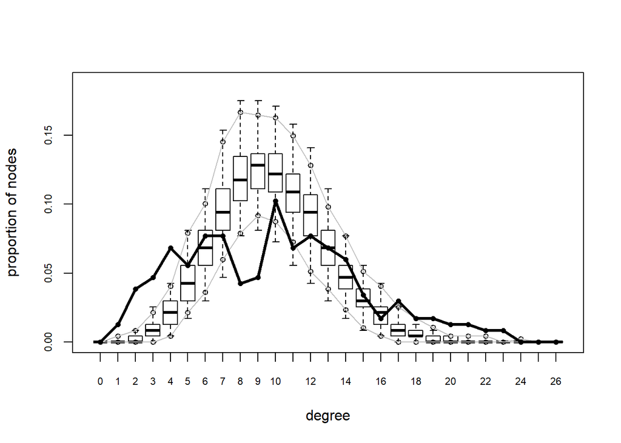

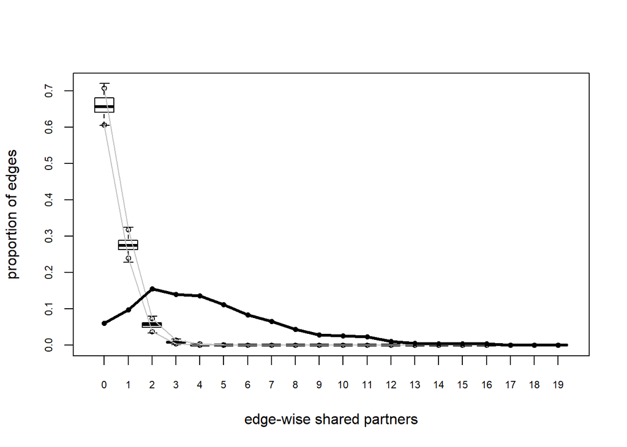

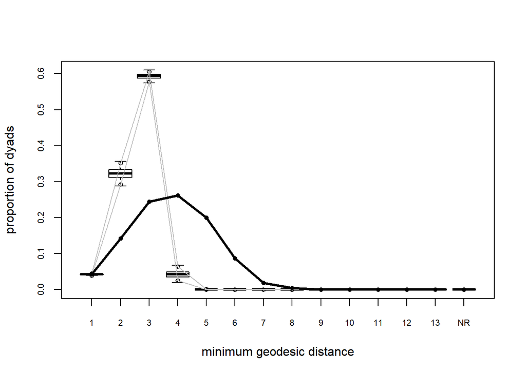

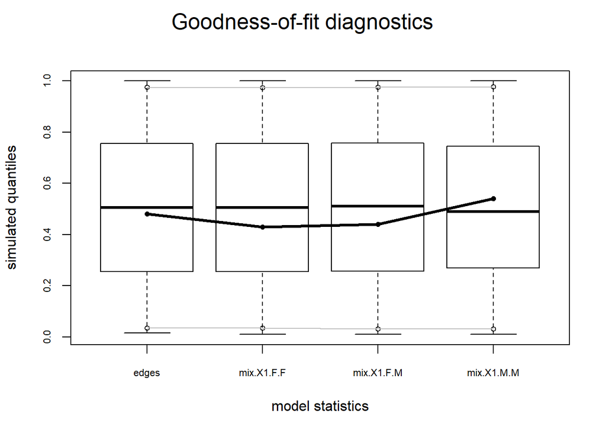

```r
plot(ga_1.m1.gof)
```

### Model 2 added Age difference and MCMC burnin

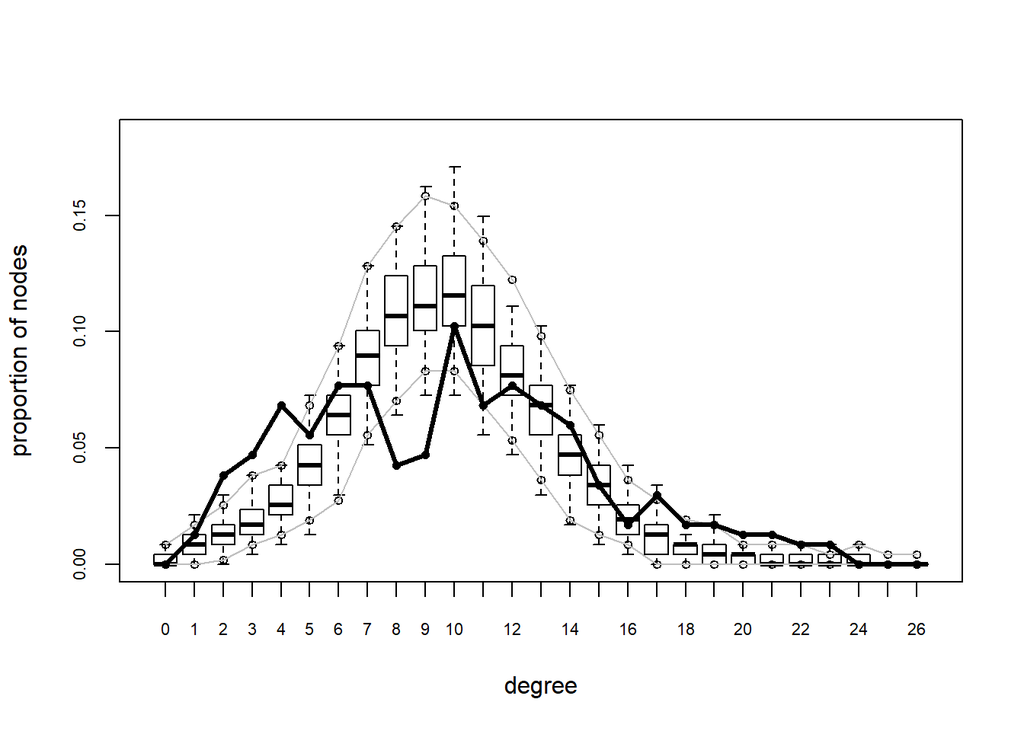

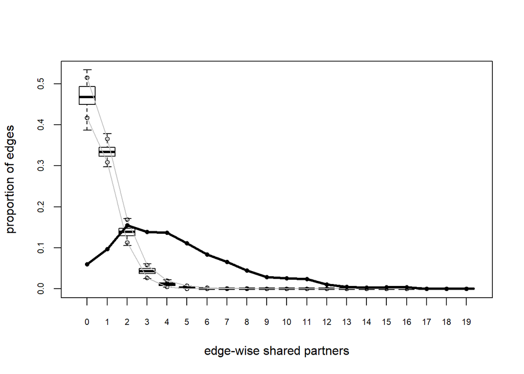

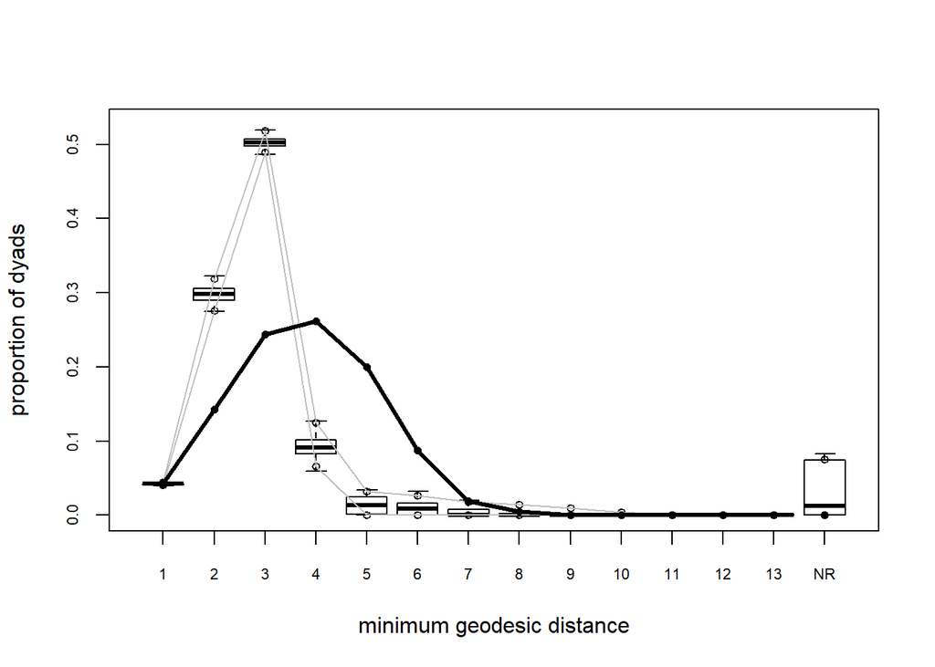

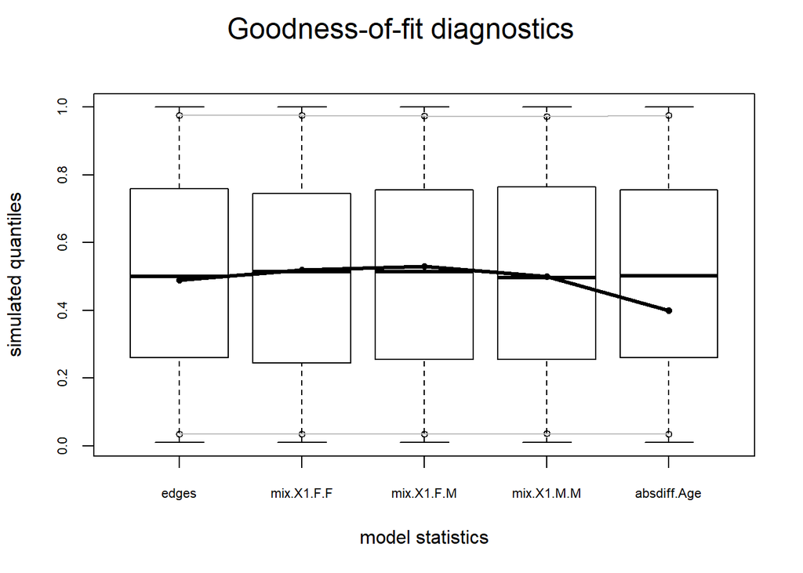

```r
## ga_1.m2 <- ergm(ga_1.net ~ edges + nodemix("X1", base=c(-1,-2,-3))+
##                absdiff("Age"),
##                control=control.ergm(MCMC.burnin = 50000,
##                                     MCMC.interval = 5000))
## ga_1.m2.gof <- gof(ga_1.m2)
plot(ga_1.m2.gof)
```

```r
summary(ga_1.m2)
```

```
##
## ==========================
## Summary of model fit
## ==========================
##
## Formula:   ga_1.net ~ edges + nodemix("X1", base = c(-1, -2, -3)) + absdiff("Age")
##
## Iterations:  7 out of 20
##
## Monte Carlo MLE Results:
##             Estimate Std. Error MCMC % p-value
## edges       -0.85584    0.11355      0  <1e-04 ***
## mix.X1.F.F  -0.98609    0.12690      0  <1e-04 ***
## mix.X1.F.M  -1.38049    0.12180      0  <1e-04 ***
## mix.X1.M.M  -0.74723    0.12358      0  <1e-04 ***
## absdiff.Age -1.13837    0.04038      0  <1e-04 ***
## ---
## Signif. codes:  0 '***' 0.001 '**' 0.01 '*' 0.05 '.' 0.1 ' ' 1
##
##      Null Deviance: 37792  on 27261  degrees of freedom
##  Residual Deviance:  8048  on 27256  degrees of freedom
##
## AIC: 8058    BIC: 8099    (Smaller is better.)
```

### Model 3

```r
## ga_1.m3 <- ergm(ga_1.net ~ edges + nodemix("X1", base=c(-1,-2,-3)) +
##                degree(1) + absdiff("Age"),
##              control=control.ergm(MCMC.burnin = 50000,
##                                   MCMC.interval = 5000))
## ga_1.m3.gof <- gof(ga_1.m3)
summary(ga_1.m3)
```

[output not shown]

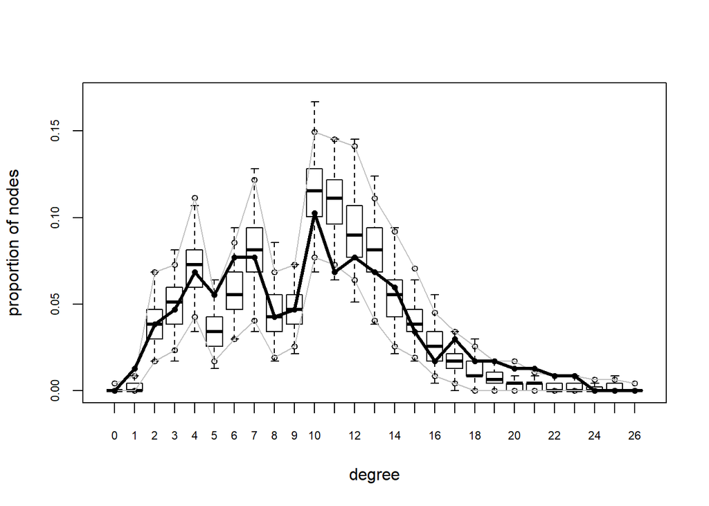

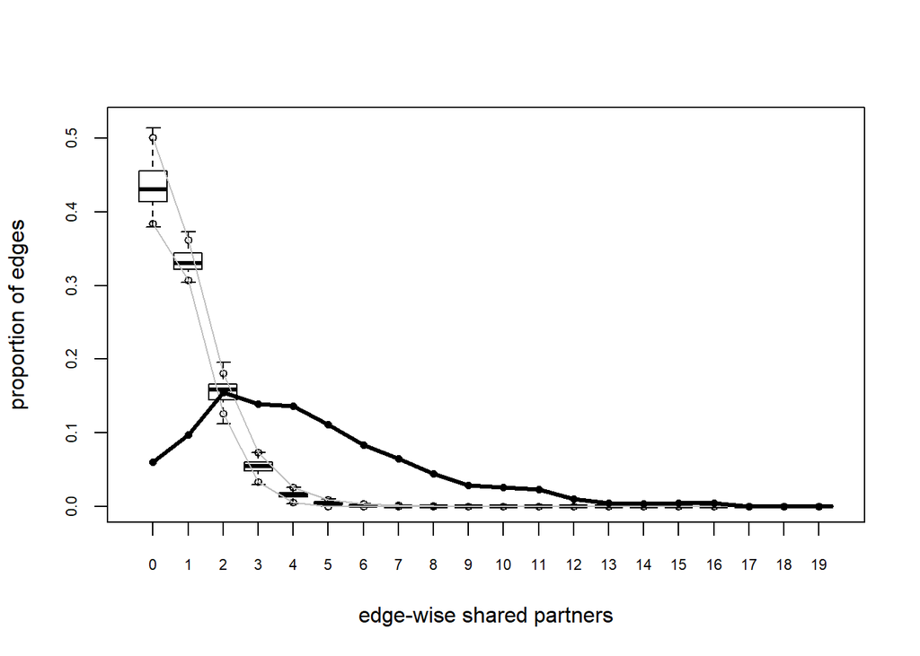

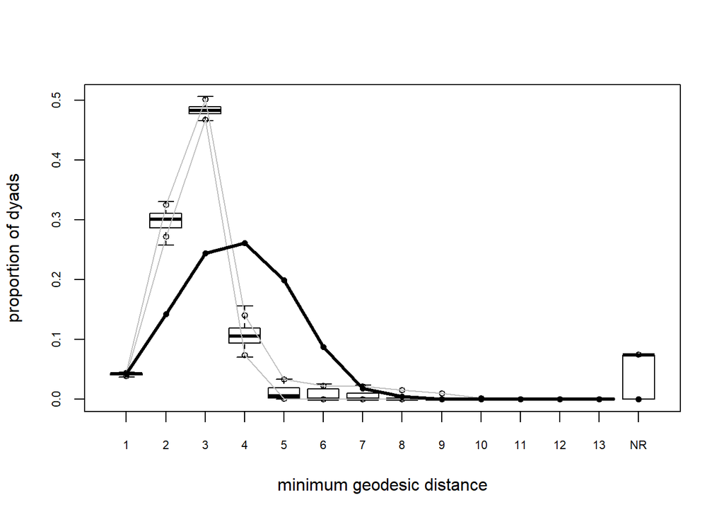

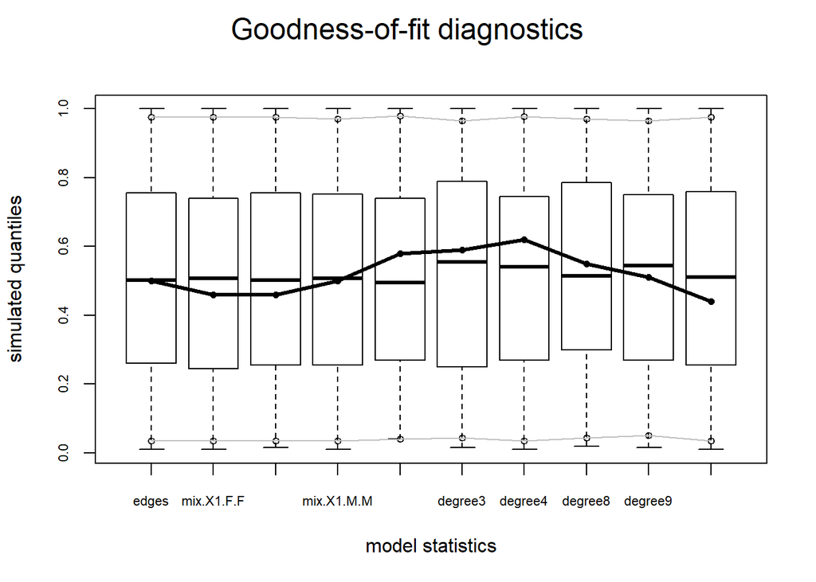

```r
plot(ga_1.m3.gof)
```

```r
## ga_1.m4 <- ergm(ga_1.net ~ edges + nodemix("X1", base=c(-1,-2,-3)) +
##                  degree(2:4) + absdiff("Age")+ gwesp(cutoff=7),
##                control=control.ergm(MCMC.burnin = 50000,
##                                     MCMC.interval = 5000))
## ga_1.m4.gof <- gof(ga_1.m4)
summary(ga_1.m4)
```

[output not shown]

```r
mcmc.diagnostics(ga_1.m4, center=F)
```

```
## Sample statistics summary:
##
## Iterations = 50000:5165000
## Thinning interval = 5000
## Number of chains = 1
## Sample size per chain = 1024
##
## 1. Empirical mean and standard deviation for each variable,
##    plus standard error of the mean:
##
##                  Mean      SD Naive SE Time-series SE
## edges        1993.991  85.432  2.66975       16.54264
## mix.X1.F.F    522.465  33.063  1.03323        4.61356
## mix.X1.F.M    709.263  42.547  1.32959        6.85926
## mix.X1.M.M    603.961  37.210  1.16280        4.44671
## degree2         4.781   2.187  0.06836        0.14928
## degree3         5.129   2.587  0.08083        0.28338
## degree4         4.176   2.386  0.07458        0.32020
## degree8         2.431   1.569  0.04904        0.07042
## degree9         2.754   1.655  0.05172        0.05783
## absdiff.Age  1240.912  76.248  2.38274        6.86244
## gwesp        4463.521 268.355  8.38610       49.36679
## gwesp.decay -2884.815 130.673  4.08354       24.39587
##
## 2. Quantiles for each variable:
##
##                2.5%     25%   50%   75%   97.5%
## edges        1813.6  1942.8  2002  2053  2140.0
## mix.X1.F.F    458.0   499.0   524   546   584.4
## mix.X1.F.M    625.6   680.8   709   740   787.4
## mix.X1.M.M    532.0   580.0   604   631   671.4
## degree2         1.0     3.0     5     6     9.0
## degree3         1.0     3.0     5     7    11.0
## degree4         0.0     2.0     4     6     9.0
## degree8         0.0     1.0     2     3     6.0
## degree9         0.0     2.0     3     4     6.0
## absdiff.Age  1079.2  1190.0  1241  1294  1386.7
## gwesp        3879.0  4300.5  4487  4657  4921.0
## gwesp.decay -3101.4 -2979.3 -2901 -2804 -2610.1
##
```

[output cut: 52 more lines]

```
## Lag 0     1.0000000 1.00000000  1.000000000   1.0000000 1.0000000
## Lag 5000  0.3854949 0.07004986  0.050475523   0.7657024 0.8839421
## Lag 10000 0.3547671 0.13405949  0.062588166   0.6057205 0.7897196
## Lag 15000 0.3339432 0.04682326 -0.020676629   0.4896142 0.7199504
## Lag 20000 0.3025383 0.06597519  0.030875139   0.3967045 0.6551354
## Lag 25000 0.3236647 0.09748826 -0.003226675   0.3314613 0.6111442
##           gwesp.decay
## Lag 0       1.0000000
## Lag 5000    0.9043520
## Lag 10000   0.8361846
## Lag 15000   0.7747848
## Lag 20000   0.7190098
## Lag 25000   0.6771558
##
## Sample statistics burn-in diagnostic (Geweke):
```

```
## Chain 1
##
## Fraction in 1st window = 0.1
## Fraction in 2nd window = 0.5
##
##       edges  mix.X1.F.F  mix.X1.F.M  mix.X1.M.M     degree2     degree3
##      0.3971      0.6746     -0.4449      0.7307     -1.4091     -1.0110
##     degree4     degree8     degree9 absdiff.Age       gwesp gwesp.decay
##     -1.0313     -1.0327     -0.3278      0.4542      0.4160     -0.4288
##
## Individual P-values (lower = worse):
##       edges  mix.X1.F.F  mix.X1.F.M  mix.X1.M.M     degree2     degree3
##   0.6913113   0.4999042   0.6563927   0.4649537   0.1587952   0.3120213
##     degree4     degree8     degree9 absdiff.Age       gwesp gwesp.decay
##   0.3024063   0.3017263   0.7430849   0.6496927   0.6774031   0.6680948
## Joint P-value (lower = worse):  0 .
```

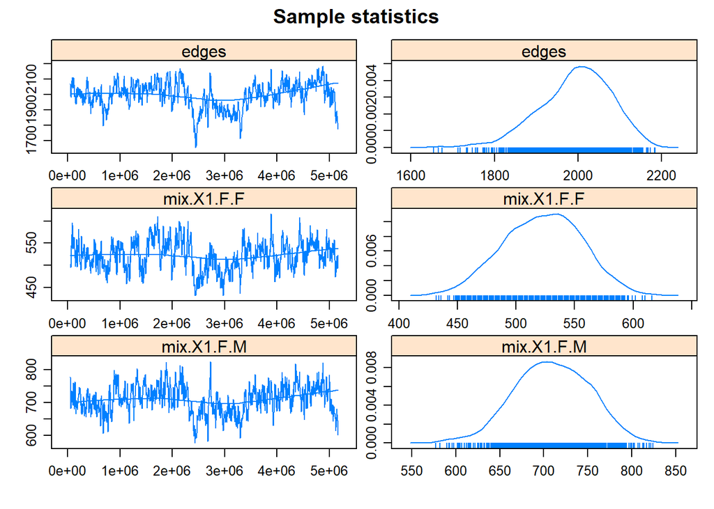

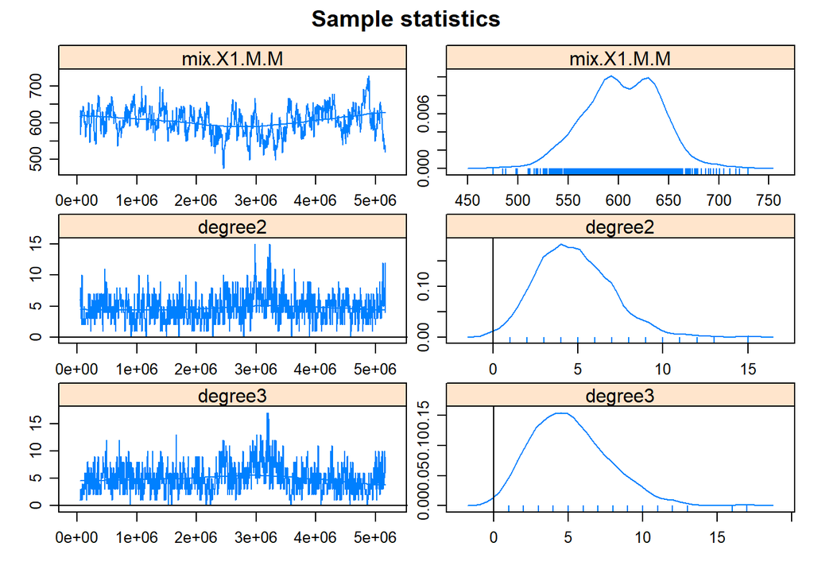

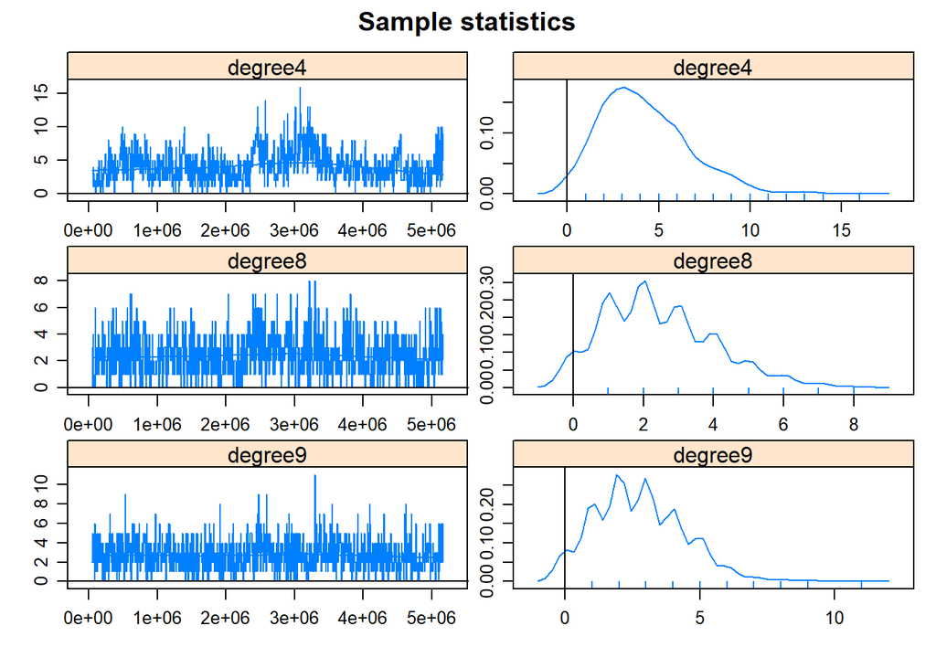

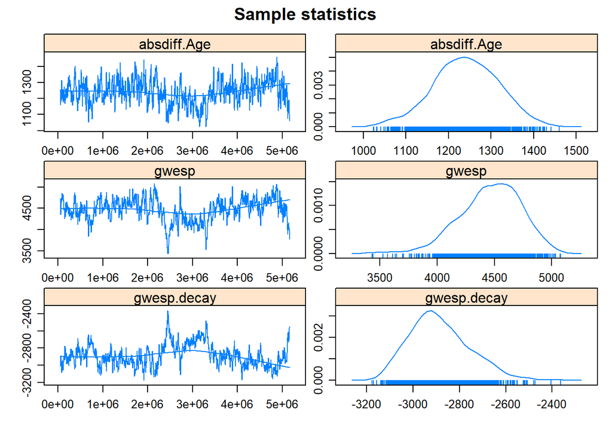

[output not shown]